# ゴーレム

**ゴーレム**：ユダヤ教の伝承に登場する自分で動く泥人形。「ゴーレム」とはヘブライ語で「胎児」の意味。作った主人の命令だけを忠実に実行する召し使いかロボットのような存在。運用上の厳格な制約が数多くあり、それを守らないと狂暴化する。（Wikipedia）

# 1.1. 統計界のゴーレム

コンピュータのコードとして生きる科学的モデルはまさに現代のゴレームである。ゴーレムのように“真実”によって命を吹き込まれるが，科学的モデルは真でも偽でもない。

古典的な$t$検定も計算の従順さから言えば小さなゴーレムである。どんな科学領域も統計のゴーレムたちに依存している。しかし，ゴーレムにはその手続き以外の知恵がない。そのため，統計学の初心者や非専門家は，ゴーレムたちに内在するモデルに見向きもせず，“検定 (test)”というゴーレムたちの動物園を道順に従って探索することになる（Figure 1.1）。

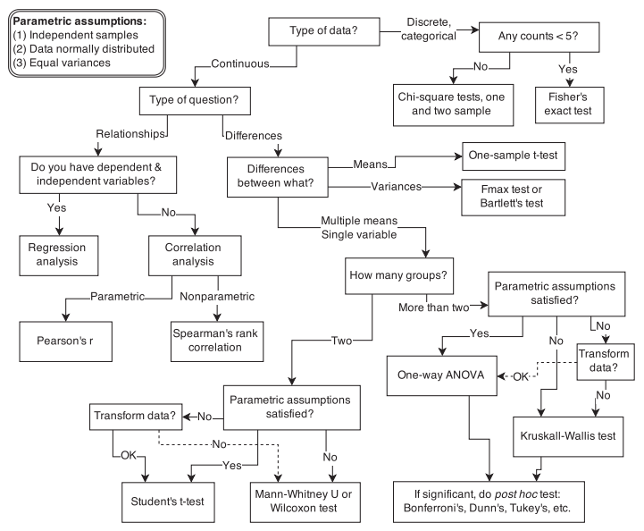

Figure 1.1

流体力学を十分知らなくても配管工が貢献するように，今後も出来合いのゴーレムたちは今後も必要であろう。但し，イノベーティブな研究では歯が立たなくなる。科学の境界領域ではどんな手続きが適切なのかすらはっきりしない。古典的なツールは多様なリサーチクエスチョンを扱うには不十分である。そこで，統計モデリングが要請されるのであるが，これは統計学の入門でも発展でも教授されない。

# 1.2 統計を再検討する

ゴーレムの情報処理方法を理解していなければ，（たとえボタン一つで結果が表示されても）ゴーレムの出力は解釈できない。このために必要とされているのは，統計モデルを十分に知ること，熱心に計算することである。しかし，そこには概念的な障壁が立ちはだかる。

最大の障壁は帰無仮説検定に対する暗黙の信念である。帰無仮説検定の考え方は「科学は反証できてナンボ」というPopperの科学観に似ているように見える。しかし，Popperが主張するほど，科学は反証基準で記述できるものではない。演繹的に反証することは科学的文脈においてはほぼ不可能である。

1. 仮説とモデルは違う。同じ仮説から多くのモデルが出てきたり，単一のモデルから多くの仮説が出てきたりする。
2. 測定が肝心。データによってモデルが反証されたかもしれないが，信用できるデータでないかもしれない。

これらの理由から，科学的方法は統計的手続きに還元できない。また，帰無仮説有意性検定（null hypothesis significance testing; NHST）は帰無仮説を反証するために用いられるものであり，その意味ではPopper的ではない。

## 1.2.1. 仮説とモデルは違う

全てのモデルは偽なのだから，モデルを反証する意味などない。 1960年代初頭，進化生物学者は進化の大部分が自然選択ではなく突然変異や浮動（drift; 繁殖成功に至る偶然性）によるという考えに関心を持っていた（分子進化の中立説; neutral models of molecular evolution）。とはいえ，自然選択の影響を疑う研究者はいなかった。

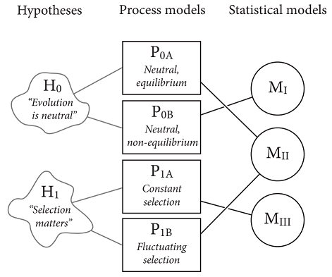

Figure 1.2

中立進化論争の模式図がFigure 1.2である。左列は仮説であり，記述的予想としてスタートするので境界が曖昧である。“中立”と名乗るモデル$H_0$は，集団の構造，対立遺伝子の数，突然変異率などの仮定により何千通りもできる。中列は具体的なプロセスモデルを表している。$P_{0A}$と$P_{0B}$は例えば，対立遺伝子の分布に対して集団サイズや構造が一定かどうかなど，一つの仮定のみ異なるモデルを表す。自然選択説 $H_1$も同様に多くのプロセスモデルを設定できる（例：自然選択に変動があるかどうか）。

プロセスモデルを証拠に照らし合わせるために，何らかの統計量についての統計モデルを作成する（例：対立遺伝子の頻度分布）。$P_{0A}$のようなモデルでは対立遺伝子の頻度分布$M_{II}$はべき法則を予測することが知られている。しかしながら，自然選択説のモデル$P_{1B}$も$M_{II}$を予測する。Figure 1.2は次の状況を表している。

1. 統計モデル$M$は一つ以上のプロセスモデル$P$と対応する可能性がある。
2. 仮説$H$は一つ以上のプロセスモデル$P$と対応する可能性がある。
3. 統計モデル$M$は一つ以上の仮説$H$と対応する可能性がある。

古典的なアプローチでは“中立”モデルを帰無仮説として扱う。しかし，$M_{II}$に即したデータが得られた場合，$P_{1B}$にも対応するから，仮説に関して棄却も採択もできない。こういった場合は，証拠の別記述や，プロセスが異なっているという記述を求めることになる。例えば，$P_{0A}$と$P_{1B}$は似通った予測をするが，対立遺伝子の変化分布の予測は非常に異なる，など。つまり，別の予測をはっきり比較する必要がある。（プロセスモデルが異なるのに統計モデルが同じようになってしまうのは，自然法則が最大エントロピー分布に従っており，さらにその分布は指数ファミリー（正規分布，二項分布，ポアソン分布など）によって表されるからである。）

## 1.2.2. 測定の問題

反証の論理はモーダス・トレンスと呼ばれる。「$H_0$: 全てのスワンは白い」という命題が，ある時，黒い羽根のスワンが見つかり，$H_0$が直ちに偽と判明する。（逆に，白いスワンを何羽観察しても$H_0$が真であることの証明にはならない。）しかしながら，科学者が抱える問題は真か偽かという2値であることはほとんどない。

第1に，観察には誤差がつきものである。2011年9月，光速よりも速いニュートリノを検出したというニュースがあった。これが正しければ，アインシュタインの特殊相対論の反証となる。物理学界の反応は「アインシュタインは間違っていた！」ではなく，「研究チームは測定ミスをした？」であった。研究チームも同じ姿勢であり，計算チェックと追試を求めた。2013年に超光速ニュートリノは測定エラーであったと合意された（ケーブルの接続に問題があった）。測定の問題は例外的に起こるものではない。

第2に，ほとんどの仮説は量的である。例えば，「スワンの$80\%$は白い」とか「黒いスワンは稀だ」というのが多くの科学的仮説である。これらの仮説は黒いスワンがいないと言っているわけではないので，たとえ黒いスワンが観察されても，モーダス・トレンスを適用することはできない。また，反証しにくいからと言って，これらの仮説が科学的仮説として良くないわけでもない。良い仮説の定義を云々することではなく，競合する仮説と比べることができる実験や観察を計画することこそ大切である。ただ，その比較も程度問題にならざるを得ないことがほとんどである。

## 1.2.3. 反証の合意性

科学の教科書に掲載されない燃素説，天動説はどのように反証されたのか。反証は常に合意によって決まるものであって，論理的なものではない。科学のコミュニティではエヴィデンスの意味するものについて議論し，コンセンサスを目指す。科学的な知識を決定的なものとして誇張すれば，科学者，科学，そして結果的には国民にも不利益を被らせてしまう。

# 1.3. ゴーレム工学のための3種の神器

反証が有用なアプローチでないことが判明した今，すべきことはモデルを作ることである。全ての統計的検定もモデルである。測定，予測，考察にもモデルが用いられる。入門的な統計学で登場する出来合いのゴーレムは多くの研究文脈にあまりマッチしない。もしゴーレムの作り手となることができれば，そのゴーレムでうまくいかない理由を把握でき，次のゴーレム作りに活かすことができる。そのための訓練が必要である。

そのためのツールは昔からあったものの，ソフトウェアの発達によりポピュラーになってきたのはつい最近である。

1. ベイジアンデータ分析
2. マルチレベルモデル
3. 情報量規準によるモデル比較

## 1.3.1. ベイジアンデータ分析

バカは運命の女神（Fortuna）頼み，賢い者は知性の神（Minerva）に訴える。統計的推論は偶然を利用して信頼ある知識を見出す。ベイジアンデータ分析は偶然に関する言語「確率論」を利用して様々な可能性の尤もらしさを記述する。

ベイズ確率は非常に一般的なアプローチで，頻度主義アプローチを特殊ケースとして含む。頻度主義者は，測定を何度も何度も繰り返せば，値のリストが得られると考えた。また，確率分布で表されるのは，パラメータやモデルではなく，測定値だけと考えた（標本分布）。架空のリサンプリングという考え方は，ベイジアンにおける不確実さを表す事前確率の利用と同じくらいファンタスティックである。

1610年，ガリレイは原始的な望遠鏡で初めて土星の輪を見た。しかし，はっきりしたイメージではなかった。但し，この不確実さは，測定の繰り返しにおける変動とは関係がない。何千回見ても，同じぼんやりしたイメージしか得られない。頻度主義的な統計的推論はたちまち躓いてしまう。一方，ベイズ推論ではノイズを確率でモデル化しする。画像処理の分野ではベイジアンアルゴリズムが支配的なのはこのためである。

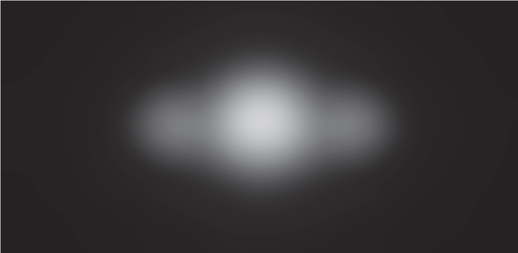

Figure 1.3

さらに情報が得られれば，正確な予測に近づいていく。ベイジアンデータ分析は情報処理のための論理的手続きである。頻度主義統計学よりもより直感的な理解ができるメリットがある。例えば，$p$値は事後確率として，信頼区間はベイズ信頼区間として直感的に解釈することができる。但し，ベイジアンモデルが非ベイジアンモデルよりも正確であるという保証はない。

## 1.3.2. マルチレベルモデル

マルチレベルモデル（階層モデルとも呼ばれる）は生物学や社会科学で必須となりつつある。なぜか？

1. 複数回のサンプリングで推定値を調整するため。同一人物から複数回の測定を行うと，単一レベルのモデルではミスリードが発生するかもしれない。
2. サンプリングのアンバランスさに対して推定値を調整するため。個々でサンプリング回数が異なる場合，単一レベルのモデルではミスリードが発生するかもしれない。
3. 変動を取り扱うため。個人間やグループ間の変動を扱える。
4. 平均化を避けるため。平均化は変動を除去する手続きであるので，オリジナルのデータをそのまま用いた方が望ましい場合にはマルチレベルモデルが良い（予測には平均値を使える）。

マルチレベルモデルは伝統的な回帰モデルよりも，フィットさせることと解釈することにおいてはかなり難しくなる。しかし，ブラックボックス的な統計から一歩踏み出すべき時である。

## 1.3.3. 情報量規準によるモデル比較

情報量規準は，将来予測の正確さに基づいてモデル比較する目的で考え出された。最も有名なものが赤池情報規準（AIC）である。モデル比較では，二つの問題を克服する必要がある。

1. オーバーフィッティング。予測に比べてフィッティングは容易である。それ故，過去データへのフィットがうまくいくからといって，予測も優れているとは限らない。
2. 複数の非ヌルモデルとの比較。

# 1.4. まとめ

帰無仮説検定のためのブラックボックス的なツールを選ぶのではなく，複数の非ヌルモデルを作り，分析するための学習をすべきである。そのためには，上記の3種の神器が必要である。

1. 確率論（2章，3章）
2. 重回帰分析（4章～7章），情報理論（6章）
3. 一般化線形モデル（8章～11章），マルコフ連鎖モンテカルロ（8章），非線形モデル（10章～14章），最大エントロピー（9章）
4. マルチレベルモデル（12章～14章）